# Estudis d'Informàtica, Multimedia i Telecomunicacions

# Mineria de dades: PRA2 - Projecte de mineria de dades

Autor: Marc Bracons Cucó

Gener 2024

# 1 Enunciat

Com a continuació de l’estudi iniciat a la Pràctica 1, procedim a **aplicar models analítics, tant no supervisats com supervisats**, sobre el joc de dades seleccionat i preparat. En aquesta **Pràctica 2** haureu de carregar les dades prèviament preparades a la **Pràctica 1**.

**Punt comú per a tots els exercicis**

En tots els apartats dels exercicis d’aquesta pràctica es demana a l’estudiant, a més d’aplicar els diferents mètodes i d’analitzar correctament el problema, **detallar de manera exhaustiva** ressaltant el perquè i com s’ha realitzat, incloent-hi elements visuals, explicant els resultats i realitzant les comparatives oportunes amb les seves conclusions.

Per a tota la pràctica és necessari documentar cada apartat de l’exercici pràctic que s’ha fet, el perquè s’ha fet i com s’ha fet. Així mateix, totes les decisions i conclusions hauran de ser presentades de forma raonada i clara, **contextualitzant els resultats**, és a dir, especificant tots i cadascun dels passos que s’hagin dut a terme per resoldre’ls.

D’aquesta manera es demana a l’estudiant que completi els passos següents amb el job de dades preparat a la Pràctica 1:

**Models no supervisats**

1. Aplicar un model **no supervisat** basat en el concepte de distància, sobre el joc de dades.
2. Aplicar de nou el model anterior, però usant una **mètrica de distància diferent** i comparar-ne els resultats amb els mètodes anteriors.
3. Utilitzar els algorismes **DBSCAN i OPTICS**, provant amb diferents valors del paràmetre `eps` i `minPts`, i es comparen els resultats amb els mètodes anteriors.

**Models supervisats**

4. Seleccionar una mostra d’entrenament i una de test utilitzant les proporcions que es considerin més adequades en funció de la disponibilitat de dades. Justificar aquesta selecció.
5. Aplicar un model de generació de regles a partir d’ **arbres de decisió** ajustant les diferents opcions de creació. Obtenir l’arbre sense i amb opcions de poda. Obtenir la matriu de confusió. Finalment, comparar-ne els resultats.
6. Aplicar un **model supervisat** diferent del del punt 5., s’ha de triar entre els que s’han vist al material docent de l’assignatura. Comparar el resultat amb el model generat anteriorment.
7. Identificar eventuals **limitacions** del dataset seleccionat i **analitzar els riscos** per al cas d’ús del model per a classificar una nova dada.

# 2 Criteris d’avaluació

- Exercici 1 - 25%
  - Es genera un model no supervisat.
  - S’analitzen, mostren i comenten les mesures de qualitat del model generat.
  - Es resumeixen les conclusions principals.
- Exercici 2 - 10%
  - Es genera de nou el model no supervisat anterior, però usant una mètrica de distància diferent.
  - Es mostren i es comenten les mesures de qualitat del model generat.
  - Addicionalment, es comparen els dos models no supervisats amb mètriques de distància diferents.
  - Es resumeixen les conclusions principals.
- Exercici 3 - 10%
  - S’apliquen els algorismes DBSCAN i OPTICS de forma correcta.
  - Es proven, descriuen i interpreten els resultats amb diferents valors d’eps i minPts.
  - S’obté una mesura de com és de bo l’agrupament.
  - Es comparen els resultats obtinguts dels models dels exercicis 1 i 2.
  - Es resumeixen les conclusions principals.
- Exercici 4 - 10%
  - Se seleccionen les mostres d’entrenament i test.
  - Es justifiquen les proporcions seleccionades.
- Exercici 5 - 20%
  - Es generen regles i es comenten i interpreten les més significatives.
  - S’extreuen les regles del model en format text i gràfic.
  - Addicionalment, es genera matriu de confusió per mesurar la capacitat predictiva de l’algoritme, tenint en compte les diferents mètriques associades a aquesta matriu (precisió, sensibilitat, especificitat…).
  - Es comparen i interpreten els resultats (sense i amb opcions de poda), explicant els avantatges i els inconvenients del model generat respecte a un altre mètode de construcció.
  - S’avalua la taxa d’error de l’arbre generat, l’eficiència a la classificació (a les mostres d’entrenament i test) i la comprensibilitat del resultat.
  - Es resumeixen les conclusions principals.
- Exercici 6 - 15%
  - Es prova amb una variació o un altre enfocament algorítmic.
  - Es detalla, comenta i avalua la qualitat de classificació.
  - Es comparen i es comenten els resultats de manera exhaustiva amb el mètode de construcció anterior.
- Exercici 7 - 10%
  - S’identifica quines possibles limitacions tenen les dades que has seleccionat per obtenir conclusions amb els models (supervisat i no supervisat)
  - S’identifiquen possibles riscos de fer servir el model (mínim 300 paraules).

# 3 Recursos de programació

- Incloem en aquest apartat una llista de recursos de programació per a mineria de dades on podreu trobar exemples, idees i inspiració:
  - [Espai de recursos UOC per a ciència de dades](http://datascience.recursos.uoc.edu/es/)
  - [Cercador de codi R](https://rseek.org/)
  - [Col·lecció de cheatsheets en R](https://rstudio.com/resources/cheatsheets/)

# 4 Format i data de lliurament

El format de lliurament és: l’output generat en format **.html** amb nom **username_estudiant-PRA2**.

La data límit de lliurament és el 17/01/2024.

# 5 RESPOSTES

## 5.1 Càrrega de dades de la pràctica 1

En aquesta segona pràctica continuarem amb l’anàlisi del joc de dades de la pràctica 1, aplicant sobre ell models analítics tant supervisats com no supervisats. El joc de dades utilitzat és l’Adult UCI Dataset (https://archive.ics.uci.edu/dataset/2/adult) (que ja ha sigut prèviament netejat) amb l’objectiu de fer prediccions sobre si una persona té uns ingressos superiors o inferiors a 50.000 dòlars anuals.

Així doncs, de forma esquemàtica els objectius són:

- Aplicar i comparar diferents models
- Documentar i raonar els passos seguits durant l’anàlisi
- Analitzar resultats i possibles limitacions del joc de dades

L’Adult UCI Dataset és un joc de dades utilitzat en l’aprenentatge automàtic i la mineria de dades. Va ser creat a partir de bases de dades del cens dels Estats Units de 1994. L’extracció de dades es va dur a terme per Barry Becker.

En aquesta pràctica treballarem amb les dades netejades de les que en farem un resum per a facilitar la lectura de l’anàlisi.

Els atributs amb els que treballarem són:

- age: edat
- fnlwgt: nombre de persones de la població de EE.UU. que una fila representa
- hours-per-week: nombre d’hores treballades a la setmana
- income-label: dos possibles valors, <=50k o >50k. És la variable sobre la que volem fer prediccions.
- nivell_educatiu: nombre associat al nivell d’estudis
- workclass: classe treballadora
- marital-status: estat civil
- occupation: ocupació
- relationship: relació de la persona amb el seu nucli familiar
- race: classificació racial
- sex: gènere de la persona
- native-country: país d’origen de la persona

Podem veure que es tracte d’un joc de dades amb informació diversa i amb dades de diferents tipus, cosa que ens permetrà classificar des de diferents punts de vista i veure quines dades aporten més informació alhora d’obtindre un model òptim.

Carreguem les dades que tenim en el document *joc_de_dades_pr1.csv*, en mostrem la dimensió i les primeres entrades.

```r
# Carreguem i visualitzem el joc de dades
ruta_fitxer <- 'joc_de_dades_pr1.csv'
df <- read.csv(ruta_fitxer)

dim(df)
```

```
## [1] 32534    12
```

```r
head(df)
```

```
##   age        workclass fnlwgt     marital.status        occupation
## 1  39        State-gov  77516      Never-married      Adm-clerical
## 2  50 Self-emp-not-inc  83311 Married-civ-spouse   Exec-managerial
## 3  38          Private 215646           Divorced Handlers-cleaners
## 4  53          Private 234721 Married-civ-spouse Handlers-cleaners
## 5  28          Private 338409 Married-civ-spouse    Prof-specialty
## 6  37          Private 284582 Married-civ-spouse   Exec-managerial
##    relationship  race    sex hours.per.week native.country income.label
## 1 Not-in-family White   Male             40  United-States        <=50K
## 2       Husband White   Male             13  United-States        <=50K
## 3 Not-in-family White   Male             40  United-States        <=50K
## 4       Husband Black   Male             40  United-States        <=50K
## 5          Wife Black Female             40           Cuba        <=50K
## 6          Wife White Female             40  United-States        <=50K
##   nivell_educatiu
## 1               4
## 2               4
## 3               3
## 4               3
## 5               4
## 6               4
```

Tenim 32534 registres, cosa que fa dificulta la realització de la pràctica ja que els temps de càrrega són molt grans. Com aquest exercici té una finalitat educacional, agafarem els primers 10.000 registres, reduint els temps de càrrega però mantenint varietat en el joc de dades.

```r
df_reduit <- head(df, 10000)

dim(df_reduit)
```

```
## [1] 10000    12
```

## 5.2 Exercici 1

### 5.2.1 Es genera un model no supervisat.

Amb això, volem identificar agrupacions naturals dins de les dades que puguin revelar patrons interessants relacionats amb els ingressos de les persones.

Per a fer-ho es seguiran els següents passos:

- Determinar nombre òptim de clústers: Aquest algorisme requereix un nombre *k* que representa el nombre de grups en què volem dividir les dades.
- Implementació de l’algorisme K-Means: Un cop tinguem decidit un valor de *k*, procedirem a l’assignació de dades als clusters. Per fer això, cada dada s’assigna al cluster més proper basat en la distància seleccionada.
- Anàlisi i interpretació dels clústers: Un cop tinguem les dades en grups visualitzarem els resultats per a veure si s’ha aconseguit una bona classificació.

No té sentit utilitzar K-Means en variables categòriques, ja que el concepte de distància no es pot aplicar a atributs com el gènere de la persona o el país d’origen. Així que primer crearem un nou dataframe en el que no hi hagi aquestes variables.

```r
df_numeric <- df_reduit[, c("age", "hours.per.week")]
head(df_numeric)
```

```
##   age hours.per.week
## 1  39             40
## 2  50             13
## 3  38             40
## 4  53             40
## 5  28             40
## 6  37             40
```

#### 5.2.1.1 Número de clústers

Una de les possibles maneres per avaluar la qualitat de l’agrupament en un conjunt de dades és el mètode de la silueta. Consisteix en mesurar com de semblants són les dades dins d’un mateix cluster en comparació amb les dades d’altres clusters. S’obté una puntuació de silueta que varia entre -1 i 1, on valors propers a 1 indiquen que el punt de dades està ben ubicat dins del seu cluster, valors propers a 0 indiquen que el punt de dades es troba en la frontera o molt a prop d’un altre cluster i, valor propers a -1 indiquen que el punt ha estat assignat al cluster equivocat.

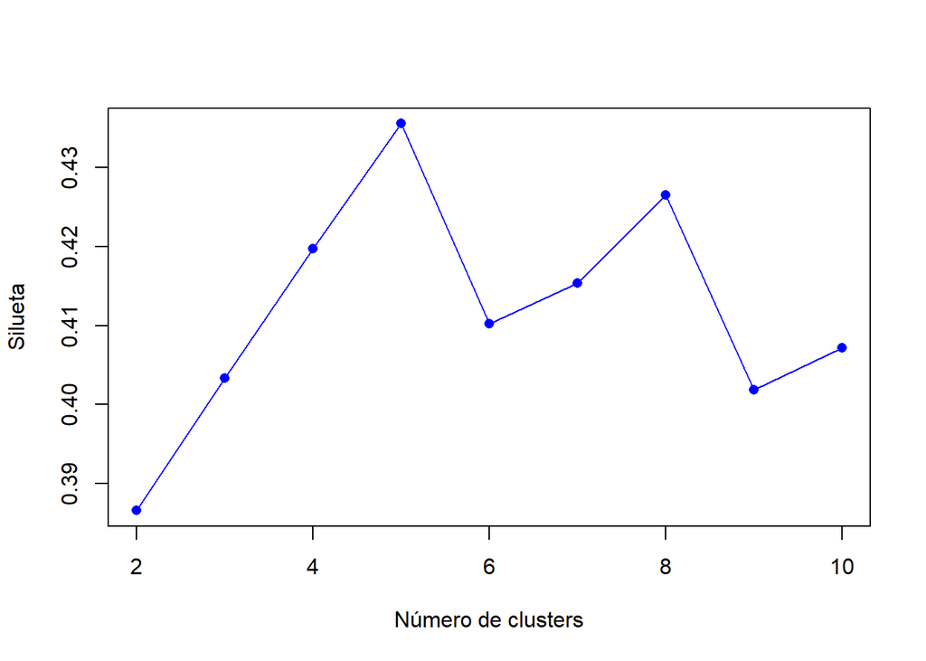

```r
library(cluster)

d <- daisy(df_numeric)
resultados <- rep(0, 10)

for (i in 2:10) {
  fit <- kmeans(df_numeric, centers = i, nstart = 25)
  y_cluster <- fit$cluster
  sk <- silhouette(y_cluster, d)
  resultados[i] <- mean(sk[, 3])
}

plot(2:10, resultados[2:10], type = "o", col = "blue", pch = 16, xlab = "Número de clusters", ylab = "Silueta")
```

El gràfic mostra que el valor màxim de la silueta es produeix amb 5 clústers, cosa que indica que aquest seria el millor valor, ja que les mostres estan més ben agrupades. Per a valors més grans la silueta disminueix, això ens indica que a mesura que anem afegint clústers, les mostres es tornen menys semblants dins dels seus respectius clústers.

Podem utilitzar altres mètriques per a avaluar el nombre de clústers. A continuació farem servir l’anàlisi de la suma dels quadrats. Aquesta mètrica mesura la variabilitat de les dades dins de cada clúster. Un valor baix indica que les mostres són molt semblants entre elles, en canvi, un valor alt ens indica una major dispersió.

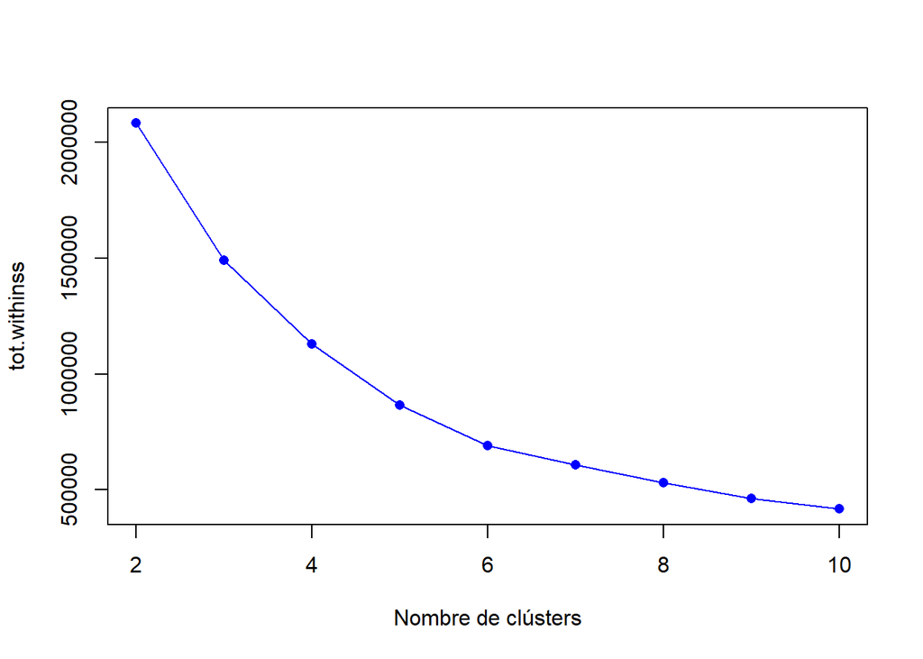

```r
resultados <- rep(0, 10)
for (i in 2:10) {
  fit <- kmeans(df_numeric, centers = i, nstart = 25)
  resultados[i] <- fit$tot.withinss
}

plot(2:10, resultados[2:10], type = "o", col = "blue", pch = 16, xlab = "Nombre de clústers", ylab = "tot.withinss")
```

Tenim coneixement previ del joc de dades i sabem que es vol fer una classificació binària (2 clústers). Així doncs, aplicarem l’algorisme per a 2 i 5 clústers i compararem els resultats.

#### 5.2.1.2 K-Means amb 5 clústers

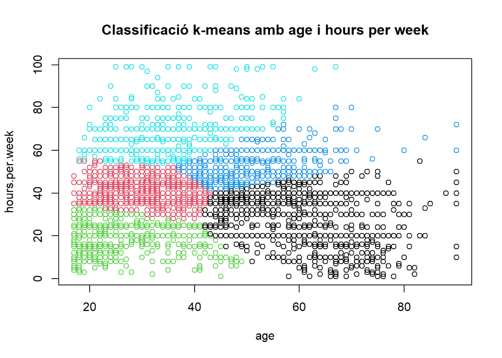

```r
income2clusters <- kmeans(df_numeric,5)
# age i hours per week
plot(df_reduit[c("age", "hours.per.week")], col=income2clusters$cluster, main="Classificació k-means amb age i hours per week")
```

En el gràfic obtingut podem veure que els 5 clústers estan separats i que pràcticament no hi ha solapament entre ells. Tot i que per als mètodes no supervisats hem hagut de treure la variable objectiu *income.label*, pot ser interessant veure com es reparteixen als clústers obtinguts aquest atribut.

```r
library(dplyr)
library(tidyr)

df_reduit$cluster <- income2clusters$cluster

cluster_income_distribution <- df_reduit %>%
  group_by(cluster, income.label) %>%
  summarise(count = n(), .groups = 'drop')

cluster_income_distribution <- cluster_income_distribution %>%
  spread(key = income.label, value = count, fill = 0)

print(cluster_income_distribution)
```

```
## # A tibble: 5 × 3
##   cluster `<=50K` `>50K`
##     <int>   <dbl>  <dbl>
## 1       1    1737    690
## 2       2    3804    806
## 3       3    1034     33
## 4       4     578    597
## 5       5     467    254
```

Podem veure la representació dels casos **>50K** en els clústers en la taula següent

[output not shown]

No hi ha cap clúster que hagi agrupat tots els casos que volíem detectar. Però donat un joc de dades, existeix més d’una agrupació possible. Així doncs, calcularem quina puntuació de silueta obtenim.

```r
silhouette_score <- silhouette(income2clusters$cluster, dist(df_numeric))
mean(silhouette_score[, "sil_width"])
```

```
## [1] 0.3847664
```

#### 5.2.1.3 K-Means amb 2 clústers

Com volem fer una classificació binària, tot i que el mètode de la silueta ens hagi indicat el contrari, utilitzarem dos clústers.

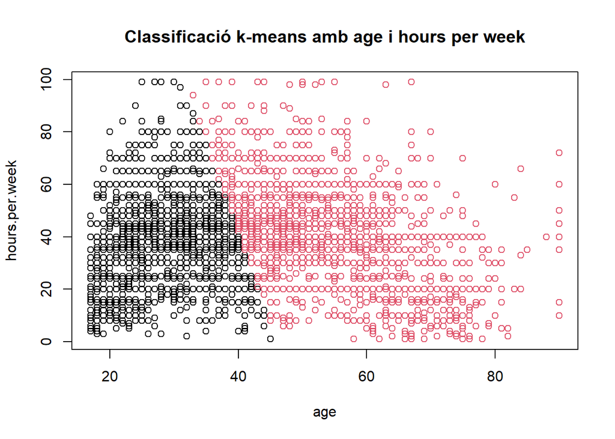

```r
income2clusters <- kmeans(df_numeric,2)
# age i hours per week
plot(df_numeric[c("age", "hours.per.week")], col=income2clusters$cluster, main="Classificació k-means amb age i hours per week")
```

Podem veure que les mostres estan separades i sense solapaments. A continuació mirarem com s’han dividit els valors de la variable objectiu en la nostra agrupació.

```r
df_reduit$cluster <- income2clusters$cluster

cluster_income_distribution <- df_reduit %>%
  group_by(cluster, income.label) %>%
  summarise(count = n(), .groups = 'drop')

cluster_income_distribution <- cluster_income_distribution %>%
  spread(key = income.label, value = count, fill = 0)

print(cluster_income_distribution)
```

```
## # A tibble: 2 × 3
##   cluster `<=50K` `>50K`
##     <int>   <dbl>  <dbl>
## 1       1    4869    862
## 2       2    2751   1518
```

Al igual que en el cas anterior, tenim els resultats en la següent taula

[output not shown]

Un altre cop no hem aconseguit que els clústers facin una agrupació on es vegin les diferències salarials dels individus.

```r
silhouette_score <- silhouette(income2clusters$cluster, dist(df_numeric))
mean(silhouette_score[, "sil_width"])
```

```
## [1] 0.3893575
```

### 5.2.2 Conclusions del model

El mètode K-means no és molt efectiu amb joc de dades que contenen moltes variables categòriques, ja que es basa en la distància entre variables com a mesura de similitud. Quan les variables són categòriques, que representen qualitats sense un ordre o quantitat, no té sentit el concepte de la distància entre elles.

## 5.3 Exercici 2

### 5.3.1 Model nou amb una altre distància

En comptes de la distància euclidiana farem servir la distància de Manhattan (norma L1), aquesta es calcula com la suma de les diferències absolutes entre les coordenades dels punts. Al igual que en l’exercici 1, al tractar-se d’un model basat en la distància, molts dels atributs del joc de dades no poden ser utilitzats. A més, en aquest cas hem procedit directament a fer una separació en dos grups.

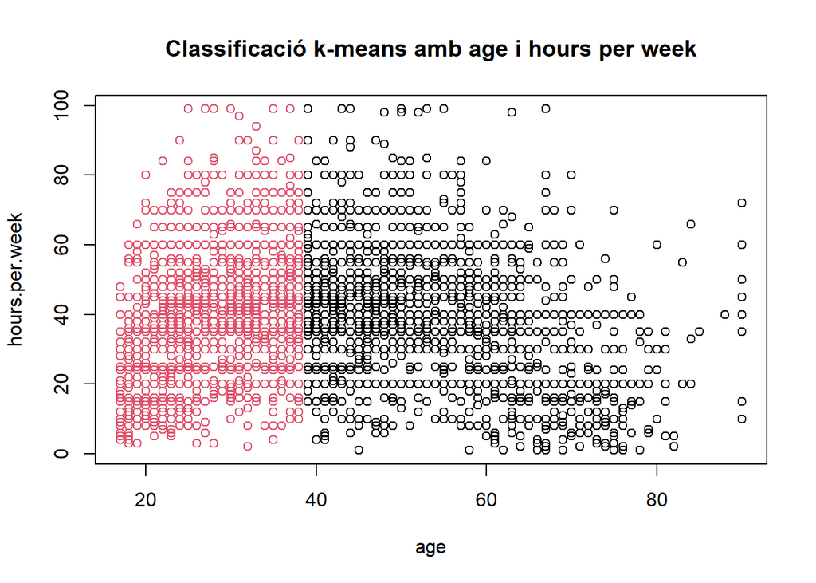

```r
income2clusters_manhattan <- pam(df_numeric, 2, metric = "manhattan")
# age i hours per week
plot(df_numeric[c("age", "hours.per.week")], col=income2clusters_manhattan$clustering, main="Classificació k-means amb age i hours per week")
```

Podem veure una separació de les dades sense solapaments, molt semblant a la de l’exercici 1. En aquest cas, també mirarem com s’han repartir els individus amb valor “>50k” de l’atribut **income.label**.

```r
df_reduit$cluster <- income2clusters_manhattan$cluster

cluster_income_distribution <- df_reduit %>%
  group_by(cluster, income.label) %>%
  summarise(count = n(), .groups = 'drop')

cluster_income_distribution <- cluster_income_distribution %>%
  spread(key = income.label, value = count, fill = 0)

print(cluster_income_distribution)
```

```
## # A tibble: 2 × 3
##   cluster `<=50K` `>50K`
##     <int>   <dbl>  <dbl>
## 1       1    3011   1585
## 2       2    4609    795
```

| cluster | <=50k | >50k | Suma | Representació |
| --- | --- | --- | --- | --- |
| 1 | 3011 | 1585 | 4596 | 34% |
| 2 | 4609 | 795 | 5404 | 15% |

Un altre cop passa el mateix, si bé en la partició no hi ha solapaments, no hem aconseguit fer una separació neta dels individus en funció de income.label.

```r
silhouette_score <- silhouette(income2clusters_manhattan$clustering, dist(df_numeric, method = "manhattan"))
mean(silhouette_score[, "sil_width"])
```

```
## [1] 0.3960057
```

El valor del coeficient és pràcticament igual, en aquest cas canviar la mètrica de la distància no ha generat un model millor.

### 5.3.2 Comparació dels dos models

Si visualitzem les particions dels dos models podem veure que les agrupacions són molt similars i que l’ús d’una mètrica de distància o un altre no supera el fet de no poder utilitzar els atributs sobre els quals el concepte de distància no té sentit.

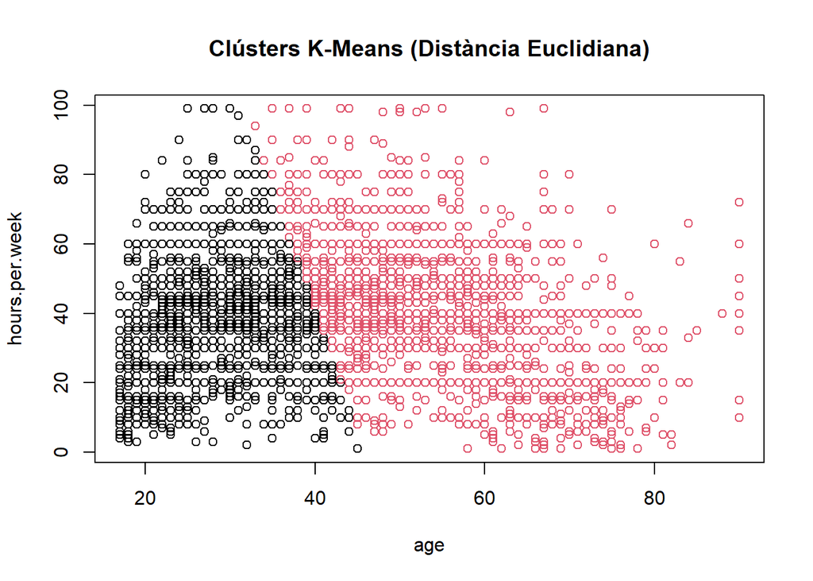

```r
plot(df_numeric[c("age", "hours.per.week")], col=income2clusters$cluster, main="Clústers K-Means (Distància Euclidiana)", xlab="age", ylab="hours.per.week")
```

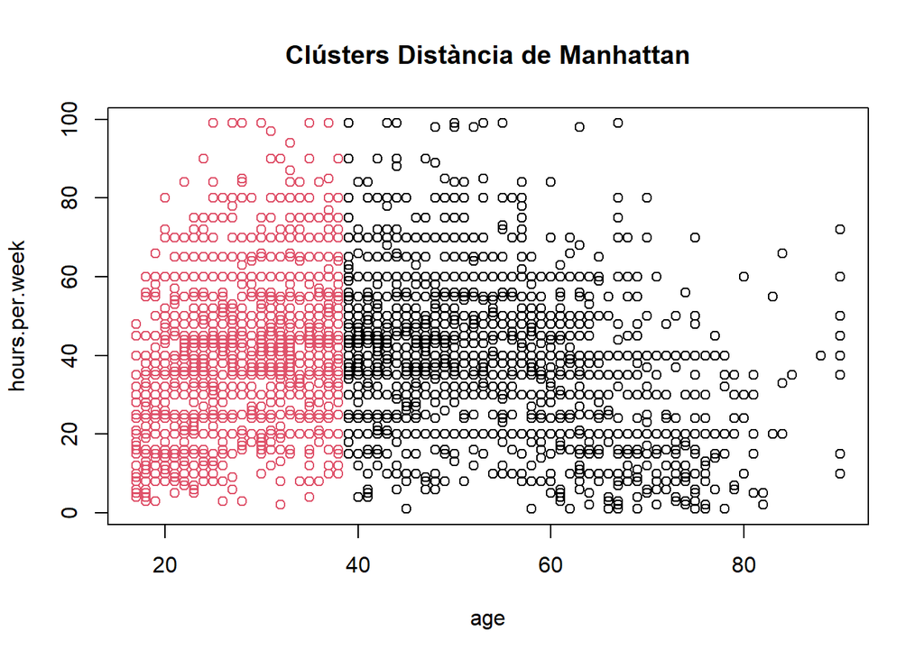

```r
plot(df_numeric[c("age", "hours.per.week")], col=income2clusters_manhattan$clustering, main="Clústers Distància de Manhattan", xlab="age", ylab="hours.per.week")
```

Fem el plot dels atributs creuats pels dos models i podem veure que en cap dels dos s’hi pot veure una classificació.

Eliminem la columna ‘cluster’ de df_reduit per a poder seguir treballant amb altres models.

```r
df_reduit <- subset(df_reduit, select = -cluster)
```

## 5.4 Exercici 3

### 5.4.1 S’apliquen els algorismes DBSCAN i OPTICS de forma correcta.

#### 5.4.1.1 Algorisme OPTICS

L’algorisme OPTICS no s’acostuma a utilitzar per a tasques de predicció directa, sinó més aviat per a l’agrupació basada en la densitat. Aquest ens pot mostrar estructures interessants de les dades, però no ens proporciona directament prediccions de classe com un model de classificació. És per això que, al igual que en els altres models no supervisats, no farem servir la variable objectiu.

```r
library('dbscan')
```

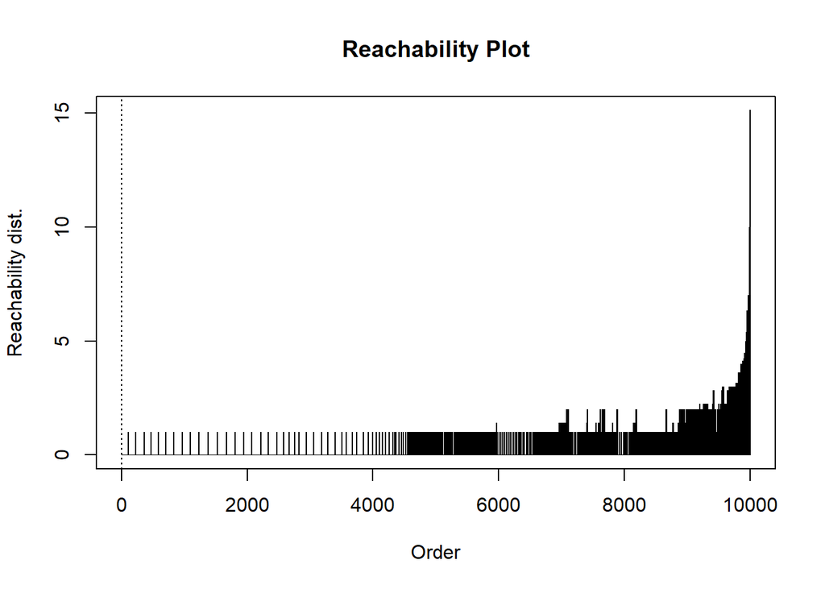

```r
res <- optics(df_numeric, minPts = 10)
plot(res)
```

El pic de la gràfica ens indica un conjunt de dades que està molt separat del altres punts, o un “outliner” en les dades. Normalitzarem les dades haviam si millora la gràfica.

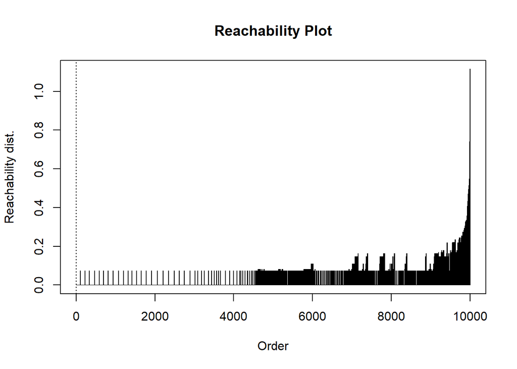

```r
library(dplyr)

# Normalització Z-score
df_numeric_normalitzat <- df_numeric %>%
  mutate_if(is.numeric, scale)

res_normalitzat <- optics(df_numeric_normalitzat, minPts = 10)
plot(res_normalitzat)
```

Després de normalitzar ja podem veure possibles clusters. A continuació modificarem el paràmetre *minPts* per estudiar l’evolució. Aquest paràmetre defineix quant de dens ha de ser el veïnatge d’un punt per a ser considerat com a nucli d’un clúster.

- Un valor més alt pot ajudar a reduir la sensibilitat als outliners
- Valors més baixos poden resultar en la detecció de més clústers (a vegades massa petits)
- També pot ajudar a determinar el nivell de tolerància al soroll en les dades.

Una regla habitual és utilitzar un valor que sigui almenys el nombre de dimensions més ú. En aquest cas *minPts=3*.

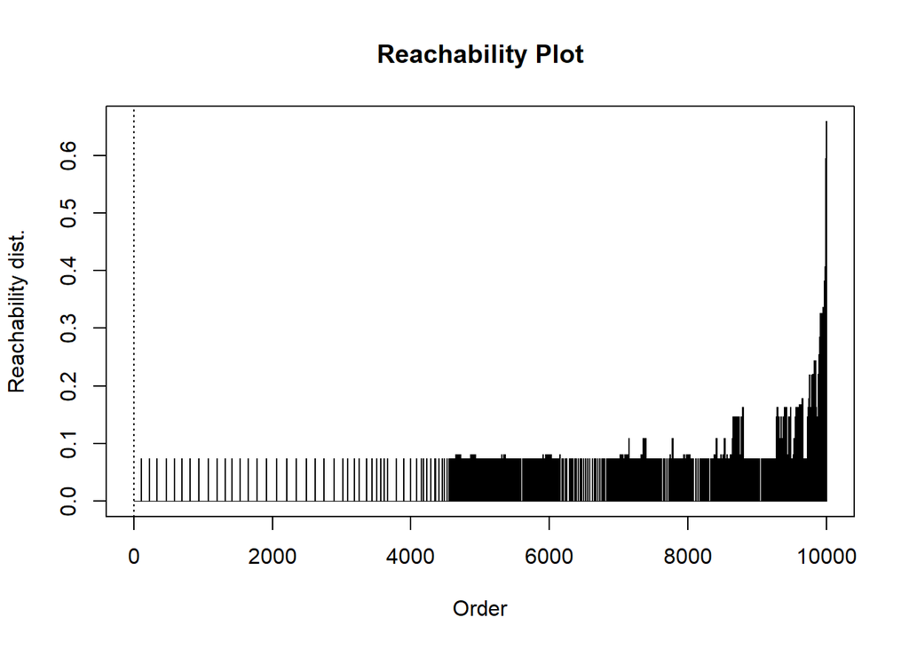

```r
res_normalitzat <- optics(df_numeric_normalitzat, minPts = 3)
plot(res_normalitzat)
```

És possible treure una agrupació de l’ordenació realitzada per OPTICS establint el paràmetre *eps* en *eps_cl = k*. Aquest paràmetre determina el llindar de distància per a decidir si els punts són veïns i pertanyen al mateix clúster, és a dir, els punts que estan per sota de la línia horitzontal de valor *eps_cl* es consideren clústers, els que estan per sobre, outliners o soroll. Ajustant el valor de *eps_cl* en valors entre 0 i 0,7 podem treure diferents nombres de clústers. En el nostre cas, com sabem que la classificació que volem fer és binària, volem trobar aquell valor que generi dos clústers.

### 5.4.2 Obtenció del valor de eps_cl

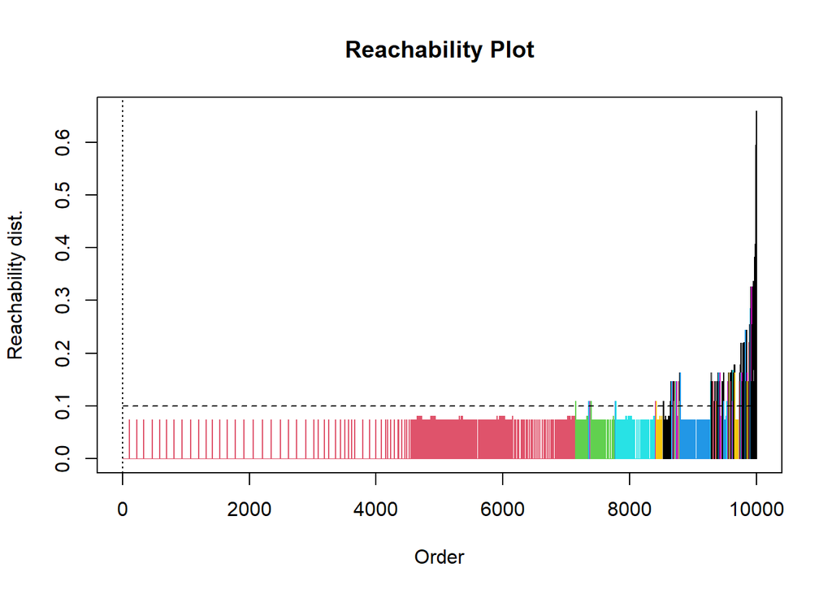

```r
res_normalitzat <- extractDBSCAN(res_normalitzat, eps_cl = 0.1)
plot(res_normalitzat)
```

Un valor molt baix genera molts clústers, en aquest cas en podem comptar més de cinc.

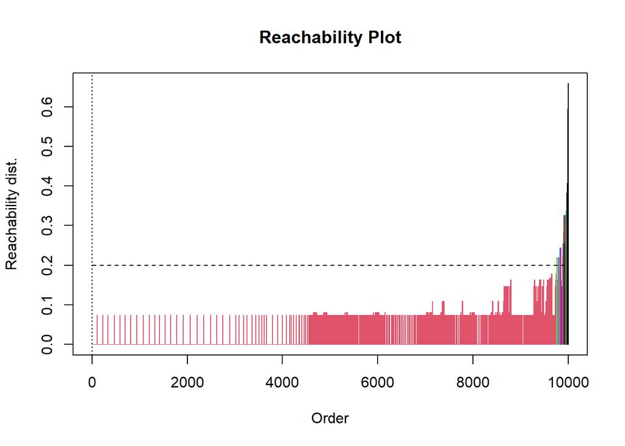

```r
res_normalitzat <- extractDBSCAN(res_normalitzat, eps_cl = 0.2)
plot(res_normalitzat)
```

Al augmentar el valor de *eps_cl* ha disminuït el nombre de clústers, tot i això encara n’hi ha més dels que voldriem.

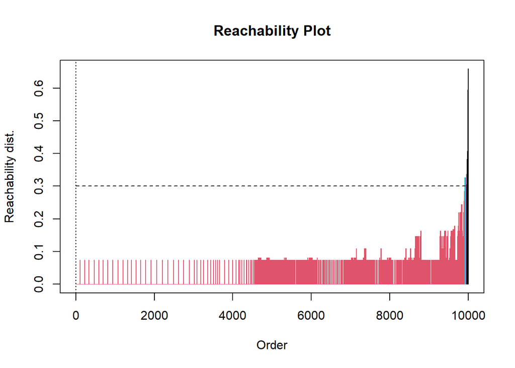

```r
res_normalitzat <- extractDBSCAN(res_normalitzat, eps_cl = 0.3)
plot(res_normalitzat)
```

Amb *eps_cl=0.3* tenim 2 clústers diferenciats, una gran part de les dades pertany al clúster pintat de vermell i l’altre al blau. Si bé hem aconseguit separar els dos grups, que un d’ells sigui tan gran ens pot donar a pensar que no s’ha fet correctament.

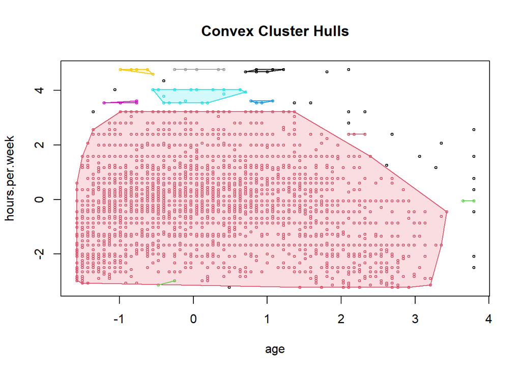

```r
hullplot(df_numeric_normalitzat, res_normalitzat)
```

Al visualitzar els clústers podem veure que de fet n’hi ha més de dos, però són tant petits que no es podia veure en la gràfica de Reachability. veiem que no hi ha solapaments entre els clústers i que, efectivament, el vermell ha agrupat la gran majoria de les dades.

### 5.4.3 Comparació amb els altres models i conclusions

Haurem de seguir amb models supervisats haviam si aquests permeten fer una millor predicció i també prediccions.

Al igual que amb els altres models no supervisats, el no poder utilitzar totes les variables ha sigut un factor determinant en els resultats dels models. Per a poder encarar el problema plantejat i obtenir prediccions sobre la variable objectiu haurem de treballar amb altres mètodes.

## 5.5 Exercici 4

Per a treballar amb models supervisats el primer que hem de fer es separar el joc de dades en dos grups, un d’entrenament i un de testing. El grup d’entrenament serà amb que ajustarem el model i amb el de testing mirarem si les prediccions obtingudes són fiables.

### 5.5.1 Es seleccionen les mostres d’entrenament i de prova.

Destinarem el 66% de les mostres a training i el 33% a testing. A més, guardarem una seed per a poder reproduir l’estudi en cas que sigui necessari. Per facilitar el procediment, mourem la columna ‘income.label’, la nostre variable objectiu, a la última posició de ‘df_reduit’.

```r
df_reduit <- df_reduit %>% select(-fnlwgt)
df_reduit <- df_reduit %>%
  mutate_if(is.character, as.factor)

income.label_col <- df_reduit$income.label
df_reduit <- df_reduit[, !(names(df_reduit) %in% c("income.label"))]
df_reduit$income.label <- income.label_col
head(df_reduit)
```

```
##   age        workclass     marital.status        occupation  relationship  race
## 1  39        State-gov      Never-married      Adm-clerical Not-in-family White
## 2  50 Self-emp-not-inc Married-civ-spouse   Exec-managerial       Husband White
## 3  38          Private           Divorced Handlers-cleaners Not-in-family White
## 4  53          Private Married-civ-spouse Handlers-cleaners       Husband Black
## 5  28          Private Married-civ-spouse    Prof-specialty          Wife Black
## 6  37          Private Married-civ-spouse   Exec-managerial          Wife White
##      sex hours.per.week native.country nivell_educatiu income.label
## 1   Male             40  United-States               4        <=50K
## 2   Male             13  United-States               4        <=50K
## 3   Male             40  United-States               3        <=50K
## 4   Male             40  United-States               3        <=50K
## 5 Female             40           Cuba               4        <=50K
## 6 Female             40  United-States               4        <=50K
```

```r
set.seed(666)
y <- df_reduit[,11]
X <- df_reduit[,1:10]
```

De manera dinàmica podem definir una manera de separar les dades en funció d’un paràmetre, en aquest cas del “split_prop”. Definim un paràmetre que controla el split de manera dinàmica en el test.

```r
split_prop <- 3
indexes = sample(1:nrow(df_reduit), size=floor(((split_prop-1)/split_prop)*nrow(df_reduit)))
trainX<-X[indexes,]
trainy<-y[indexes]
testX<-X[-indexes,]
testy<-y[-indexes]
```

Ara és un bon moment per veure un resum dels conjunts de test i train per veure que tot ha sortit correctament i que la proporció de income.label és la mateixa que al joc de dades original.

```r
summary(trainX)
```

```
##       age                   workclass                  marital.status
##  Min.   :17.00   Private         :5048   Divorced             : 921
##  1st Qu.:27.00   Self-emp-not-inc: 539   Married-AF-spouse    :   4
##  Median :37.00   Local-gov       : 417   Married-civ-spouse   :3014
##  Mean   :38.42   State-gov       : 251   Married-spouse-absent:  79
##  3rd Qu.:48.00   Self-emp-inc    : 231   Never-married        :2241
##  Max.   :90.00   Federal-gov     : 179   Separated            : 200
##                  (Other)         :   1   Widowed              : 207
##            occupation           relationship                  race
##  Adm-clerical   :1129   Husband       :2646   Amer-Indian-Eskimo:  63
##  Exec-managerial: 835   Not-in-family :1732   Asian-Pac-Islander: 204
##  Prof-specialty : 835   Other-relative: 206   Black             : 608
##  Sales          : 794   Own-child     :1053   Other             :  62
##  Craft-repair   : 792   Unmarried     : 695   White             :5729
##  Other-service  : 679   Wife          : 334
##  (Other)        :1602
##      sex       hours.per.week        native.country nivell_educatiu
##  Female:2195   Min.   : 1.00   United-States:6079   Min.   :1.000
##  Male  :4471   1st Qu.:40.00   Mexico       : 135   1st Qu.:3.000
##                Median :40.00   Philippines  :  37   Median :3.000
##                Mean   :40.58   Canada       :  31   Mean   :3.252
##                3rd Qu.:45.00   Germany      :  29   3rd Qu.:4.000
##                Max.   :99.00   Puerto-Rico  :  25   Max.   :5.000
##                                (Other)      : 330
```

```r
trainy <- as.factor(trainy)
summary(trainy)
```

```
## <=50K  >50K
##  5098  1568
```

```r
summary(testX)
```

```
##       age                   workclass                  marital.status
##  Min.   :17.00   Private         :2484   Divorced             : 465
##  1st Qu.:28.00   Self-emp-not-inc: 264   Married-AF-spouse    :   3
##  Median :37.00   Local-gov       : 228   Married-civ-spouse   :1540
##  Mean   :38.51   State-gov       : 149   Married-spouse-absent:  52
##  3rd Qu.:47.00   Self-emp-inc    : 114   Never-married        :1068
##  Max.   :90.00   Federal-gov     :  93   Separated            : 121
##                  (Other)         :   2   Widowed              :  85
##            occupation          relationship                  race
##  Adm-clerical   :585   Husband       :1354   Amer-Indian-Eskimo:  36
##  Exec-managerial:437   Not-in-family : 857   Asian-Pac-Islander: 104
##  Prof-specialty :421   Other-relative:  89   Black             : 345
##  Craft-repair   :415   Own-child     : 513   Other             :  21
##  Sales          :385   Unmarried     : 359   White             :2828
##  Other-service  :348   Wife          : 162
##  (Other)        :743
##      sex       hours.per.week        native.country nivell_educatiu
##  Female:1103   Min.   : 1.00   United-States:3033   Min.   :1.00
##  Male  :2231   1st Qu.:40.00   Mexico       :  72   1st Qu.:3.00
##                Median :40.00   Canada       :  16   Median :3.00
##                Mean   :40.45   Germany      :  16   Mean   :3.25
##                3rd Qu.:45.00   El-Salvador  :  14   3rd Qu.:4.00
##                Max.   :99.00   Philippines  :  14   Max.   :5.00
##                                (Other)      : 169
```

```r
testy <- as.factor(testy)
summary(testy)
```

```
## <=50K  >50K
##  2522   812
```

Podem veure que ara tenim moltes més variables amb les que treballar. Pel que fa a la variable objectiu, la proporció de casos on pren el valor “>50k” és semblant en l’entrenament i en el testing (al voltant del 24%).

### 5.5.2 justificació de les proporcions seleccionades

Al tindre moltes dades podem destinar una bona part del joc de dades a testing. Podem observar que la proporció de casos on income.label és “<=50k” és major que en la que és “>50k” en els dos conjunts, a més, la proporció és la mateixa en els dos conjunts i en el joc de dades original.

A més, un 33% de les dades destinades a testing ens proporciona una quantitat suficient de dades per una raonable avaluació del rendiment del model. A més, és una convenció bastant estàndard en aquest tipus d’exercicis, basada en l’experiència i resultats anteriors. ***

## 5.6 Exercici 5

### 5.6.1 Creació del model, qualitat del model i extracció de regles

```r
library(C50)
set.seed(666)
trainy = as.factor(trainy)
model <- C50::C5.0(trainX, trainy,rules=TRUE )
summary(model)
```

```
##
## Call:
## C5.0.default(x = trainX, y = trainy, rules = TRUE)
##
##
## C5.0 [Release 2.07 GPL Edition]      Sun Jan 14 20:00:25 2024
## -------------------------------
##
## Class specified by attribute `outcome'
##
## Read 6666 cases (11 attributes) from undefined.data
##
## Rules:
##
## Rule 1: (1700/20, lift 1.3)
##  age <= 29
##  relationship in {Not-in-family, Other-relative, Own-child, Unmarried}
##  ->  class <=50K  [0.988]
##
## Rule 2: (784/16, lift 1.3)
##  workclass in {Local-gov, Private, Self-emp-not-inc, State-gov}
##  occupation in {Adm-clerical, Craft-repair, Farming-fishing,
##                        Handlers-cleaners, Machine-op-inspct, Other-service,
##                        Priv-house-serv, Protective-serv, Transport-moving}
##  hours.per.week <= 34
##  ->  class <=50K  [0.978]
##
## Rule 3: (1700/52, lift 1.3)
##  age <= 27
##  ->  class <=50K  [0.969]
##
## Rule 4: (181/5, lift 1.3)
##  workclass = Private
##  occupation in {Prof-specialty, Sales}
##  hours.per.week <= 39
##  nivell_educatiu <= 3
##  ->  class <=50K  [0.967]
##
## Rule 5: (2910/110, lift 1.3)
##  relationship in {Not-in-family, Other-relative, Own-child, Unmarried}
```

[output cut: 138 more lines]

```
##     669   899    (b): class >50K
##
##
##  Attribute usage:
##
##   81.59% workclass
##   78.71% nivell_educatiu
##   78.61% relationship
##   66.41% occupation
##   63.44% age
##   58.73% hours.per.week
##   47.22% race
##
##
## Time: 0.1 secs
```

L’algorisme **C5.0** del paquet **C50** ha generat un resultat en el que hi tenim 24 regles. A més, podem veure que workclass és l’atribut més utilitzat (81.59%), indicant que la classe treballadora d’una persona és un factor clau per a la predicció dels seus ingressos. A continuació hi tenim el nivell edutaciu (78,71%) seguit de relationship (78,61%), l’ocupació (66,41%), edat (63.44%), hores setmanals (58.73%) i la raça (47,22%).

Crida l’atenció que el restat de la relació sentimental tingui un pes més alt que l’edat o l’ocupació.

A continuació podem dibuixar l’arbre obtingut,

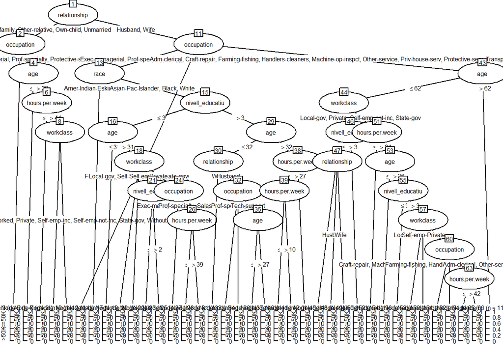

```r
library(grid)
model <- C50::C5.0(trainX, trainy)
plot(model,gp = gpar(fontsize = 6))
```

### 5.6.2 Validació del model amb les dades de testing

Per a evaluar el model obtingut farem servir les dades de testing, calculant primer de tot la precisió del model.

```r
predicted_model <- predict( model, testX, type="class" )
print(sprintf("La precisió de l'árbre és: %.4f %%",100*sum(predicted_model == testy) / length(predicted_model)))
```

```
## [1] "La precisió de l'árbre és: 82.6635 %"
```

A més, sempre és útil fer servir la matriu de confusió per veure els falsos postius, falsos negatius, verdaders positius i verdaders negatius.

```r
library(gmodels)
CrossTable(testy, predicted_model,prop.chisq  = FALSE, prop.c = FALSE, prop.r =FALSE,dnn = c('Reality', 'Prediction'))
```

```
##
##
##    Cell Contents
## |-------------------------|
## |                       N |
## |         N / Table Total |
## |-------------------------|
##
##
## Total Observations in Table:  3334
##
##
##              | Prediction
##      Reality |     <=50K |      >50K | Row Total |
## -------------|-----------|-----------|-----------|
##        <=50K |      2335 |       187 |      2522 |
##              |     0.700 |     0.056 |           |
## -------------|-----------|-----------|-----------|
##         >50K |       391 |       421 |       812 |
##              |     0.117 |     0.126 |           |
## -------------|-----------|-----------|-----------|
## Column Total |      2726 |       608 |      3334 |
## -------------|-----------|-----------|-----------|
##
##
```

- True Positives (TP): El model ha predit correctament la classe “<=50K”. Aquí, 2335 és el nombre de TP.
- False Positives (FP): El model ha predit incorrectament la classe “<=50K quan en realitat era la classe”>50K”. Aquí, 391 és el nombre de FP.
- False Negatives (FN): El model ha predit incorrectament la classe “>50K” quan en realitat era la classe “<=50K. Aquí, 187 és el nombre de FN.
- True Negatives (TN): El model ha predit correctament la classe “>50K”. Aquí, 421 és el nombre de TN.

Hi ha 2522 observacions que són realment de la classe “<=50K”, de les quals el model n’ha predit correctament 2335. Això dóna una taxa de sensibilitat de 2335/2522 = 92% per a la classe “<=50K”.

Hi ha 812 observacions que són realment de la classe “>50K”, de les quals el model n’ha predit correctament 421 com a classe “>50K”. Això dóna una taxa d’especificitat de 421/812 = 52% per a la classe “>50K”.

El model està funcionant millor per predir la classe “<=50K” que no pas la classe “>50K”. Això pot ser degut al desbalanceig de classes que hi ha en el joc de dades.

## 5.7 Exercici 6

El paquet **C50** i l’algorisme **C5.0** implementen un mètode de poda automàtica. És a dir, durant l’entrenament ja s’han eliminat les branquen que no aporten informació significativa. Per a tal de aportar alguna modificació el que farem és un bosc.

```r
library(randomForest)
set.seed(666)
model_randomForest <- randomForest(x = trainX, y = trainy, ntree = 50, )
predicted_model_randomForest <- predict(model_randomForest, testX, type="class")
print(sprintf("La precisió de l'árbre amb ntree = 50 és: %.4f %%",100*sum(predicted_model_randomForest == testy) / length(predicted_model_randomForest)))
```

```
## [1] "La precisió de l'árbre amb ntree = 50 és: 82.6335 %"
```

```r
CrossTable(testy, predicted_model_randomForest,prop.chisq  = FALSE, prop.c = FALSE, prop.r =FALSE,dnn = c('Reality', 'Prediction'))
```

```
##
##
##    Cell Contents
## |-------------------------|
## |                       N |
## |         N / Table Total |
## |-------------------------|
##
##
## Total Observations in Table:  3334
##
##
##              | Prediction
##      Reality |     <=50K |      >50K | Row Total |
## -------------|-----------|-----------|-----------|
##        <=50K |      2297 |       225 |      2522 |
##              |     0.689 |     0.067 |           |
## -------------|-----------|-----------|-----------|
##         >50K |       354 |       458 |       812 |
##              |     0.106 |     0.137 |           |
## -------------|-----------|-----------|-----------|
## Column Total |      2651 |       683 |      3334 |
## -------------|-----------|-----------|-----------|
##
##
```

```r
set.seed(666)
class_weights <- c(1, 2.3)
model_randomForest <- randomForest(x = trainX, y = trainy, ntree = 50, classwt = class_weights)
predicted_model_randomForest <- predict(model_randomForest, testX, type="class")
print(sprintf("La precisió de l'árbre amb ntree = 50 i amb pesos modificats és: %.4f %%",100*sum(predicted_model_randomForest == testy) / length(predicted_model_randomForest)))
```

```
## [1] "La precisió de l'árbre amb ntree = 50 i amb pesos modificats és: 79.3941 %"
```

```r
CrossTable(testy, predicted_model_randomForest,prop.chisq  = FALSE, prop.c = FALSE, prop.r =FALSE,dnn = c('Reality', 'Prediction'))
```

```
##
##
##    Cell Contents
## |-------------------------|
## |                       N |
## |         N / Table Total |
## |-------------------------|
##
##
## Total Observations in Table:  3334
##
##
##              | Prediction
##      Reality |     <=50K |      >50K | Row Total |
## -------------|-----------|-----------|-----------|
##        <=50K |      2009 |       513 |      2522 |
##              |     0.603 |     0.154 |           |
## -------------|-----------|-----------|-----------|
##         >50K |       174 |       638 |       812 |
##              |     0.052 |     0.191 |           |
## -------------|-----------|-----------|-----------|
## Column Total |      2183 |      1151 |      3334 |
## -------------|-----------|-----------|-----------|
##
##
```

La precisió del model ha baixat al 79%, però hem pogut classificar millor els casos poc representats en el joc de dades. Ara el que farem és fer una anàlisi del nombre d’arbres necessaris per a obtenir la millor precisió, mantenint els pesos modificats.

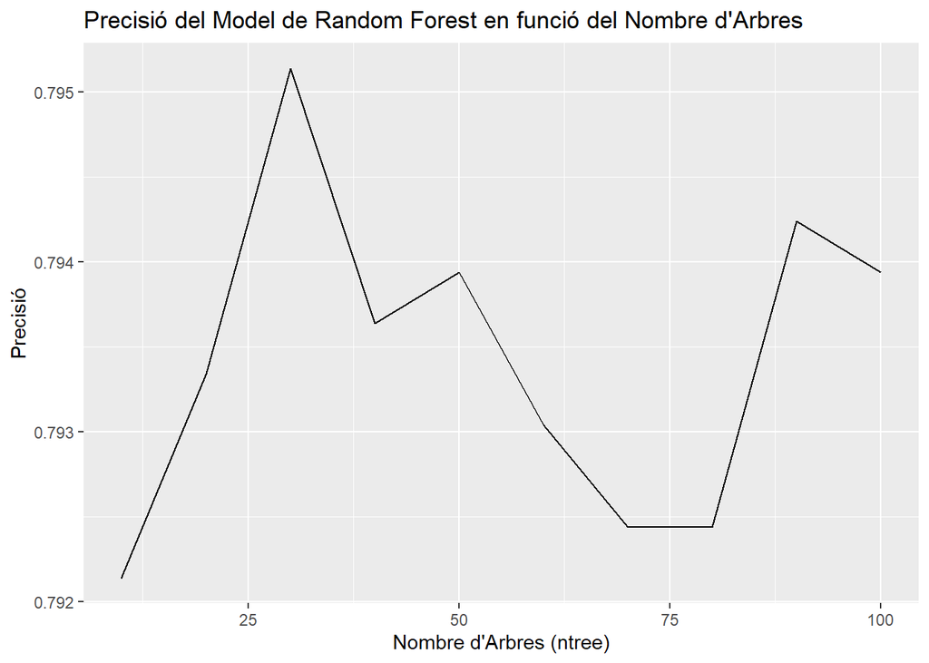

```r
library(ggplot2)
valors_ntree <- seq(10, 100, by = 10)
precisions <- numeric(length(valors_ntree))

class_weights <- c(1, 2.3)
for (i in seq_along(valors_ntree)) {
    set.seed(666)
    model <- randomForest(x = trainX, y = trainy, ntree = valors_ntree[i], classwt = class_weights)
    predictions <- predict(model, testX)
    precisions[i] <- sum(predictions == testy) / length(testy)
}

resultats <- data.frame(ntree = valors_ntree, accuracy = precisions)

ggplot(resultats, aes(x = ntree, y = accuracy)) +
    geom_line() +
    xlab("Nombre d'Arbres (ntree)") +
    ylab("Precisió") +
    ggtitle("Precisió del Model de Random Forest en funció del Nombre d'Arbres")
```

```r
index_max_precisio <- which.max(resultats$accuracy)
max_precisio <- resultats$accuracy[index_max_precisio]
ntree_max_precisio <- resultats$ntree[index_max_precisio]
print(paste("La precisió màxima és", max_precisio, "amb", ntree_max_precisio, "arbres."))
```

```
## [1] "La precisió màxima és 0.795140971805639 amb 30 arbres."
```

El gràfic ens indica que el màxim de precisió el tindrem amb 30 arbres, així que generem el model amb aquest valor.

```r
set.seed(666)
class_weights <- c(1, 2.3)
model_randomForest <- randomForest(x = trainX, y = trainy, ntree = 30, classwt = class_weights)
predicted_model_randomForest <- predict(model_randomForest, testX, type="class")
print(sprintf("La precisió de l'árbre amb ntree = 30 és: %.4f %%",100*sum(predicted_model_randomForest == testy) / length(predicted_model_randomForest)))
```

```
## [1] "La precisió de l'árbre amb ntree = 30 és: 79.5141 %"
```

```r
CrossTable(testy, predicted_model_randomForest,prop.chisq  = FALSE, prop.c = FALSE, prop.r =FALSE,dnn = c('Reality', 'Prediction'))
```

```
##
##
##    Cell Contents
## |-------------------------|
## |                       N |
## |         N / Table Total |
## |-------------------------|
##
##
## Total Observations in Table:  3334
##
##
##              | Prediction
##      Reality |     <=50K |      >50K | Row Total |
## -------------|-----------|-----------|-----------|
##        <=50K |      2019 |       503 |      2522 |
##              |     0.606 |     0.151 |           |
## -------------|-----------|-----------|-----------|
##         >50K |       180 |       632 |       812 |
##              |     0.054 |     0.190 |           |
## -------------|-----------|-----------|-----------|
## Column Total |      2199 |      1135 |      3334 |
## -------------|-----------|-----------|-----------|
##
##
```

La precisió del model en fer les prediccions és del 79,5%, aquest pot semblar un valor baix, però és un resultat molt millor del que hem aconseguit amb els altres mètodes. S’han obtingut models amb precisions més altes, però aquest és el millor fent prediccions correctament la classe menys representativa (hem aconseguit que detecti les dues classes amb aproximadament un 80% de precisió)

És important entendre el joc de dades que s’està estudiant i valorar quines mètriques són les més importants per a definir com de bo és un model. En aquest cas he decidit dona importància a la detecció de casos en què **income.label** és “>50K” i després de tots els models possibles he buscat la màxima precisió.

## 5.8 Exercici 7

### 5.8.1 S’identifica quines possibles limitacions tenen les dades que has seleccionat per obtenir conclusions amb els models (supervisat i no supervisat)

Les limitacions de les dades són diferents en funció de l’algorisme triat per a l’obtenció del model.

Per als models no supervisats, la falta de tindre més dades numèriques no categòriques ha sigut un factor determinant en els resultats, ja que d’un joc de dades amb molta informació només n’hem pogut aprofitar un petit tant per cent.

L’algorisme K-Means no gestiona bé les variables categòriques, ja que calcula la mitjana dels punts del cluster. A més, assumeix que els clusters són de forma esfèrica i de mida similar, cosa que ha sigut un problema en el joc de dades, ja que la partició de la variable objectiu no era de proporcions iguals. El mateix ha passat amb l’algorisme OPTICS i DBSCAN.

Pel que fa als models supervisats, sempre s’ha de tindre en compte que aquests mètodes són propensos al sobreajustament. El joc de dades ha permès evitar-lo ja que teníem moltes dades amb les que treballar. Aquests models si que han permès l’ús de variables categòriques, però el fet que n’hi hagi tantes incrementa la complexitat de l’arbre.

El model obtingut amb randomForest ha sigut el que millors resultats ha donat, ja que hem equilibrat els pesos de les classes del joc de dades i a més, al igual que en l’altre model supervisat, hem pogut fer servir les variables categòriques.

### 5.8.2 S’identifiquen possibles riscos de fer servir el model (mínim 300 paraules).

El model que creat té alguns aspectes a considerar. Primer, pot reproduir els errors o biaixos presents en les dades amb què ha estat entrenat. Això pot ser problemàtic, especialment si utilitzem les mateixes dades per avaluar el model, ja que pot semblar més precís del que realment és.

Tot i això, el model té una precisió del 80%, una xifra que pot ser suficient en alguns àmbits, però insuficient en altres, com en decisions econòmiques importants.

Cal també considerar com els errors de classificació del model poden afectar diferentment segons el context. Un error en un àmbit pot ser més greu que en un altre. Per exemple, un marge d’error del 20% pot ser massa alt en situacions que afecten significativament la vida de les persones.

Un altre punt important és que les dades utilitzades es van recollir el 1994, i podrien no ser representatives de la situació actual, tenint en compte els canvis socials, econòmics i tecnològics.

És essencial també que el conjunt de dades representi adequadament la diversitat de la població a la qual s’aplicarà el model. La manca de representació de certs grups o situacions pot fer que el model no sigui efectiu per a aquestes poblacions.

A més, és important actualitzar el model regularment per assegurar que segueixi sent rellevant i precís davant canvis en les dades.

Finalment, no podem oblidar les implicacions ètiques de l’ús del model, incloent qüestions de discriminació, privacitat i consentiment. És fonamental que el model no perjudiqui grups específics ni exacerbi desigualtats existents.

Tenint en compte tots els avantatges dels models basats en dades, és vital ser conscients dels seus límits, l’impacte dels errors, la necessitat de mantenir les dades actualitzades i la importància de considerar aspectes ètics. Així podrem assegurar que els models serveixin justament a tothom, sense perpetuar biaixos o injustícies.